# Oxford-Comma-Tidyverse-Part-1

Michael Y.

due 12/08/2019

# TidyVerse assignment, due on 12/08

In this assignment, you’ll practice collaborating around a code project with GitHub.  
You could consider our collective work as building out a book of examples on how to use TidyVerse functions.

GitHub repository: https://github.com/acatlin/FALL2019TIDYVERSE

[FiveThirtyEight.com datasets](https://data.fivethirtyeight.com/) .

[Kaggle datasets](https://www.kaggle.com/datasets) .

## You have two tasks:

## 1. Create an Example.

Using one or more TidyVerse packages, and any dataset from [fivethirtyeight.com](https://data.fivethirtyeight.com/) or [Kaggle](https://www.kaggle.com/datasets), create a programming sample “vignette” that demonstrates how to use one or more of the capabilities of the selected TidyVerse package with your selected dataset. **(25 points)**

### Oxford Comma dataset

In June of 2014, `FiveThirtyEight.com` ran an online poll (using “surveymonkey.com”) asking Americans whether they preferred the serial comma (also known as the `Oxford Comma`.)

Additional questions were posed regarding the respondents’ educational level, income level, age, and what part of the country each person was from.

Additional grammatical questions which were part of the same poll concerned usage of the word “data”: respondents were asked whether they considered “data” to be *singular* or *plural*.

Following conclusion of the poll, FiveThirtyEight.com published a piece *Elitist, Superfluous, Or Popular? We Polled Americans on the Oxford Comma*$^1$ and made the **underlying dataset**$^2$ available on github .

#### **Variables in the dataset**

The raw dataset contains 1129 cases, each of which represents a response to an online poll conducted in June 2014, where participants were asked various questions, including:

1. whether they knew what the Oxford Comma is,
2. which of two sentences (one with the serial comma, and one without) they preferred, and
3. whether they believed the use of proper grammar was important.

Additionally, participants were asked questions regarding their gender, age, income, educational attainment, and geographic region.

The overall dataset includes the following variables and possible responses:

[output not shown]

So, other than the initial column, all the remaining columns are factors.

#### `readr::read_csv`: Initial attempt to load up the data from fivethirtyeight’s github site:

```r
commadataURL <- "https://raw.githubusercontent.com/fivethirtyeight/data/master/comma-survey/comma-survey.csv"
### Read the data using read_csv from tidyverse package readr
tv_commadata <- read_csv(commadataURL)
```

#### Without my having made any column specifications, `read_csv` hasn’t read in the data as we would like:

```r
# First 5 cases
tv_commadata %>% head(5)
```

```
## # A tibble: 5 x 13
##   RespondentID `In your opinio~ `Prior to readi~ `How much, if a~ `How would you ~ `When faced wit~ `How much, if a~ `In your opinio~ Gender
##          <dbl> <chr>            <chr>            <chr>            <chr>            <chr>            <chr>            <chr>            <chr>
## 1   3292953864 It's important ~ Yes              Some             Some experts sa~ No               Not much         Somewhat import~ Male
## 2   3292950324 It's important ~ No               Not much         Some experts sa~ No               Not much         Somewhat unimpo~ Male
## 3   3292942669 It's important ~ Yes              Some             Some experts sa~ Yes              Not at all       Very important   Male
## 4   3292932796 It's important ~ Yes              Some             Some experts sa~ No               Some             Somewhat import~ Male
## 5   3292932522 It's important ~ No               Not much         Some experts sa~ No               Not much         <NA>             <NA>
## # ... with 4 more variables: Age <chr>, `Household Income` <chr>, Education <chr>, `Location (Census Region)` <chr>
```

```r
# First 5 cases, transposed:
tv_commadata %>% head(5) %>% t
```

```
##                                                                                                                        [,1]
## RespondentID                                                                                                           "3292953864"
## In your opinion, which sentence is more gramatically correct?                                                          "It's important for a person to be honest, kind and loyal."
## Prior to reading about it above, had you heard of the serial (or Oxford) comma?                                        "Yes"
## How much, if at all, do you care about the use (or lack thereof) of the serial (or Oxford) comma in grammar?           "Some"
## How would you write the following sentence?                                                                            "Some experts say it's important to drink milk, but the data is inconclusive."
## When faced with using the word "data", have you ever spent time considering if the word was a singular or plural noun? "No"
## How much, if at all, do you care about the debate over the use of the word "data" as a singluar or plural noun?        "Not much"
## In your opinion, how important or unimportant is proper use of grammar?                                                "Somewhat important"
## Gender                                                                                                                 "Male"
## Age                                                                                                                    "30-44"
## Household Income                                                                                                       "$50,000 - $99,999"
## Education                                                                                                              "Bachelor degree"
## Location (Census Region)                                                                                               "South Atlantic"
##                                                                                                                        [,2]
## RespondentID                                                                                                           "3292950324"
## In your opinion, which sentence is more gramatically correct?                                                          "It's important for a person to be honest, kind, and loyal."
## Prior to reading about it above, had you heard of the serial (or Oxford) comma?                                        "No"
## How much, if at all, do you care about the use (or lack thereof) of the serial (or Oxford) comma in grammar?           "Not much"
## How would you write the following sentence?                                                                            "Some experts say it's important to drink milk, but the data is inconclusive."
## When faced with using the word "data", have you ever spent time considering if the word was a singular or plural noun? "No"
## How much, if at all, do you care about the debate over the use of the word "data" as a singluar or plural noun?        "Not much"
## In your opinion, how important or unimportant is proper use of grammar?                                                "Somewhat unimportant"
## Gender                                                                                                                 "Male"
## Age                                                                                                                    "30-44"
## Household Income                                                                                                       "$50,000 - $99,999"
## Education                                                                                                              "Graduate degree"
## Location (Census Region)                                                                                               "Mountain"
##                                                                                                                        [,3]
## RespondentID                                                                                                           "3292942669"
## In your opinion, which sentence is more gramatically correct?                                                          "It's important for a person to be honest, kind, and loyal."
## Prior to reading about it above, had you heard of the serial (or Oxford) comma?                                        "Yes"
## How much, if at all, do you care about the use (or lack thereof) of the serial (or Oxford) comma in grammar?           "Some"
## How would you write the following sentence?                                                                            "Some experts say it's important to drink milk, but the data is inconclusive."
## When faced with using the word "data", have you ever spent time considering if the word was a singular or plural noun? "Yes"
## How much, if at all, do you care about the debate over the use of the word "data" as a singluar or plural noun?        "Not at all"
## In your opinion, how important or unimportant is proper use of grammar?                                                "Very important"
## Gender                                                                                                                 "Male"
## Age                                                                                                                    "30-44"
## Household Income                                                                                                       NA
```

[output cut: 15 more lines]

```
## Location (Census Region)                                                                                               "Middle Atlantic"
##                                                                                                                        [,5]
## RespondentID                                                                                                           "3292932522"
## In your opinion, which sentence is more gramatically correct?                                                          "It's important for a person to be honest, kind and loyal."
## Prior to reading about it above, had you heard of the serial (or Oxford) comma?                                        "No"
## How much, if at all, do you care about the use (or lack thereof) of the serial (or Oxford) comma in grammar?           "Not much"
## How would you write the following sentence?                                                                            "Some experts say it's important to drink milk, but the data is inconclusive."
## When faced with using the word "data", have you ever spent time considering if the word was a singular or plural noun? "No"
## How much, if at all, do you care about the debate over the use of the word "data" as a singluar or plural noun?        "Not much"
## In your opinion, how important or unimportant is proper use of grammar?                                                NA
## Gender                                                                                                                 NA
## Age                                                                                                                    NA
## Household Income                                                                                                       NA
## Education                                                                                                              NA
## Location (Census Region)                                                                                               NA
```

```r
tv_commadata %>%
  head(5) %>%
  t %>%
  kable() %>%
  kable_styling(c("striped", "bordered"))
```

| RespondentID | 3292953864 | 3292950324 | 3292942669 | 3292932796 | 3292932522 |
| --- | --- | --- | --- | --- | --- |
| In your opinion, which sentence is more gramatically correct? | It’s important for a person to be honest, kind and loyal. | It’s important for a person to be honest, kind, and loyal. | It’s important for a person to be honest, kind, and loyal. | It’s important for a person to be honest, kind, and loyal. | It’s important for a person to be honest, kind and loyal. |
| Prior to reading about it above, had you heard of the serial (or Oxford) comma? | Yes | No | Yes | Yes | No |
| How much, if at all, do you care about the use (or lack thereof) of the serial (or Oxford) comma in grammar? | Some | Not much | Some | Some | Not much |
| How would you write the following sentence? | Some experts say it’s important to drink milk, but the data is inconclusive. | Some experts say it’s important to drink milk, but the data is inconclusive. | Some experts say it’s important to drink milk, but the data is inconclusive. | Some experts say it’s important to drink milk, but the data is inconclusive. | Some experts say it’s important to drink milk, but the data is inconclusive. |
| When faced with using the word “data”, have you ever spent time considering if the word was a singular or plural noun? | No | No | Yes | No | No |
| How much, if at all, do you care about the debate over the use of the word “data” as a singluar or plural noun? | Not much | Not much | Not at all | Some | Not much |
| In your opinion, how important or unimportant is proper use of grammar? | Somewhat important | Somewhat unimportant | Very important | Somewhat important | NA |
| Gender | Male | Male | Male | Male | NA |
| Age | 30-44 | 30-44 | 30-44 | 18-29 | NA |
| Household Income | $50,000 - $99,999 | $50,000 - $99,999 | NA | NA | NA |
| Education | Bachelor degree | Graduate degree | NA | Less than high school degree | NA |
| Location (Census Region) | South Atlantic | Mountain | East North Central | Middle Atlantic | NA |

```r
tv_commadata %>% summary %>%
  kable() %>%
  kable_styling(c("striped", "bordered"))
```

|  | RespondentID | In your opinion, which sentence is more gramatically correct? | Prior to reading about it above, had you heard of the serial (or Oxford) comma? | How much, if at all, do you care about the use (or lack thereof) of the serial (or Oxford) comma in grammar? | How would you write the following sentence? | When faced with using the word “data”, have you ever spent time considering if the word was a singular or plural noun? | How much, if at all, do you care about the debate over the use of the word “data” as a singluar or plural noun? | In your opinion, how important or unimportant is proper use of grammar? | Gender | Age | Household Income | Education | Location (Census Region) |
| --- | --- | --- | --- | --- | --- | --- | --- | --- | --- | --- | --- | --- | --- |
|  | Min. :3288375700 | Length:1129 | Length:1129 | Length:1129 | Length:1129 | Length:1129 | Length:1129 | Length:1129 | Length:1129 | Length:1129 | Length:1129 | Length:1129 | Length:1129 |
|  | 1st Qu.:3289469695 | Class :character | Class :character | Class :character | Class :character | Class :character | Class :character | Class :character | Class :character | Class :character | Class :character | Class :character | Class :character |
|  | Median :3290113576 | Mode :character | Mode :character | Mode :character | Mode :character | Mode :character | Mode :character | Mode :character | Mode :character | Mode :character | Mode :character | Mode :character | Mode :character |
|  | Mean :3290127075 | NA | NA | NA | NA | NA | NA | NA | NA | NA | NA | NA | NA |
|  | 3rd Qu.:3290776606 | NA | NA | NA | NA | NA | NA | NA | NA | NA | NA | NA | NA |
|  | Max. :3292953864 | NA | NA | NA | NA | NA | NA | NA | NA | NA | NA | NA | NA |

It read in the first column as a double, and all of the remaining columns as characters.

In reality, we want each of the remaining columns to be a **factor**, with only a few possible responses.

#### `readr::spec_csv()` can specify the type of each column

```r
tv_columnspec = paste0(c("n",rep("f",12)),collapse="")
tv_columnspec
```

```
## [1] "nffffffffffff"
```

This indicates that the first column is numeric, and each of the remaining 12 columns is a factor.

##### Check result with `readr::spec_csv`

```r
spec_csv(commadataURL, col_types=tv_columnspec)
```

[output not shown]

#### `readr::read_csv`: Re-load the data, this time specifying the above column types:

```r
tv_commadata <- read_csv(commadataURL, col_types = tv_columnspec)
tv_commadata %>% summary
```

```
##   RespondentID                                   In your opinion, which sentence is more gramatically correct?
##  Min.   :3288375700   It's important for a person to be honest, kind and loyal. :488
##  1st Qu.:3289469695   It's important for a person to be honest, kind, and loyal.:641
##  Median :3290113576
##  Mean   :3290127075
##  3rd Qu.:3290776606
##  Max.   :3292953864
##
##  Prior to reading about it above, had you heard of the serial (or Oxford) comma?
##  Yes :655
##  No  :444
##  NA's: 30
##
##
##
##
##  How much, if at all, do you care about the use (or lack thereof) of the serial (or Oxford) comma in grammar?
##  Some      :414
##  Not much  :268
##  A lot     :291
##  Not at all:126
##  NA's      : 30
##
##
##                                                         How would you write the following sentence?
##  Some experts say it's important to drink milk, but the data is inconclusive. :865
##  Some experts say it's important to drink milk, but the data are inconclusive.:228
##  NA's                                                                         : 36
##
##
##
##
##  When faced with using the word "data", have you ever spent time considering if the word was a singular or plural noun?
##  No  :547
##  Yes :544
##  NA's: 38
##
##
##
##
```

[output cut: 9 more lines]

```
##  Somewhat important                         :333                                Male  :489   30-44:254   $50,000 - $99,999  :290
##  Somewhat unimportant                       :  7                                Female:548   18-29:221   $25,000 - $49,999  :158
##  Very important                             :688                                NA's  : 92   > 60 :272   $0 - $24,999       :121
##  Very unimportant                           :  5                                             45-60:290   $150,000+          :103
##  Neither important nor unimportant (neutral): 26                                             NA's : 92   $100,000 - $149,999:164
##  NA's                                       : 70                                                         NA's               :293
##
##                             Education         Location (Census Region)
##  Bachelor degree                 :344   Pacific           :180
##  Graduate degree                 :276   East North Central:170
##  Less than high school degree    : 11   South Atlantic    :164
##  Some college or Associate degree:295   Middle Atlantic   :140
##  High school degree              :100   West South Central: 88
##  NA's                            :103   (Other)           :285
##                                         NA's              :102
```

Now the data are all recognized as (unordered) factors.

#### The initial variable names were awful.

##### `dplyr::bind_cols()` as tidyverse equivalent to cbind() :

```r
initial_variable_names <- names(tv_commadata)

# index the variable names using bind_cols from dplyr
bind_cols(column=seq(initial_variable_names),
          InitialVariableName=initial_variable_names) %>%
  kable() %>%
  kable_styling(c("striped", "bordered"))
```

| column | InitialVariableName |
| --- | --- |
| 1 | RespondentID |
| 2 | In your opinion, which sentence is more gramatically correct? |
| 3 | Prior to reading about it above, had you heard of the serial (or Oxford) comma? |
| 4 | How much, if at all, do you care about the use (or lack thereof) of the serial (or Oxford) comma in grammar? |
| 5 | How would you write the following sentence? |
| 6 | When faced with using the word “data”, have you ever spent time considering if the word was a singular or plural noun? |
| 7 | How much, if at all, do you care about the debate over the use of the word “data” as a singluar or plural noun? |
| 8 | In your opinion, how important or unimportant is proper use of grammar? |
| 9 | Gender |
| 10 | Age |
| 11 | Household Income |
| 12 | Education |
| 13 | Location (Census Region) |

Because these “variables” are so long, it is difficult to display the information.  
I’ll replace each column header with a succinct name, while saving the above questions in an array.

#### `dplyr::rename_all`: rename all of the variable names::

```r
new_variable_names <- c("RespondentID",
                        "USES_Oxford",
                        "HEARD_Oxford",
                        "CARE_Oxford",
                        "DATA_Sentence",
                        "DATA_Plural",
                        "DATA_Care",
                        "Grammar_Important",
                        "Gender",
                        "AgeBands",
                        "IncomeBands",
                        "Education",
                        "Location")

tv_commadata <- tv_commadata %>% rename_all( function(.){new_variable_names} )
tv_commadata %>% summary
```

```
##   RespondentID                                                            USES_Oxford  HEARD_Oxford     CARE_Oxford
##  Min.   :3288375700   It's important for a person to be honest, kind and loyal. :488   Yes :655     Some      :414
##  1st Qu.:3289469695   It's important for a person to be honest, kind, and loyal.:641   No  :444     Not much  :268
##  Median :3290113576                                                                    NA's: 30     A lot     :291
##  Mean   :3290127075                                                                                 Not at all:126
##  3rd Qu.:3290776606                                                                                 NA's      : 30
##  Max.   :3292953864
##
##                                                                        DATA_Sentence DATA_Plural      DATA_Care
##  Some experts say it's important to drink milk, but the data is inconclusive. :865   No  :547    Not much  :403
##  Some experts say it's important to drink milk, but the data are inconclusive.:228   Yes :544    Not at all:203
##  NA's                                                                         : 36   NA's: 38    Some      :352
##                                                                                                  A lot     :133
##                                                                                                  NA's      : 38
##
##
##                                    Grammar_Important    Gender     AgeBands                IncomeBands
##  Somewhat important                         :333     Male  :489   30-44:254   $50,000 - $99,999  :290
##  Somewhat unimportant                       :  7     Female:548   18-29:221   $25,000 - $49,999  :158
##  Very important                             :688     NA's  : 92   > 60 :272   $0 - $24,999       :121
##  Very unimportant                           :  5                  45-60:290   $150,000+          :103
##  Neither important nor unimportant (neutral): 26                  NA's : 92   $100,000 - $149,999:164
##  NA's                                       : 70                              NA's               :293
##
##                             Education                 Location
##  Bachelor degree                 :344   Pacific           :180
##  Graduate degree                 :276   East North Central:170
##  Less than high school degree    : 11   South Atlantic    :164
##  Some college or Associate degree:295   Middle Atlantic   :140
##  High school degree              :100   West South Central: 88
##  NA's                            :103   (Other)           :285
##                                         NA's              :102
```

#### Here are the first five records:

```r
tv_commadata %>%
  head(5)
```

```
## # A tibble: 5 x 13
##   RespondentID USES_Oxford HEARD_Oxford CARE_Oxford DATA_Sentence DATA_Plural DATA_Care Grammar_Importa~ Gender AgeBands IncomeBands
##          <dbl> <fct>       <fct>        <fct>       <fct>         <fct>       <fct>     <fct>            <fct>  <fct>    <fct>
## 1   3292953864 It's impor~ Yes          Some        Some experts~ No          Not much  Somewhat import~ Male   30-44    $50,000 - ~
## 2   3292950324 It's impor~ No           Not much    Some experts~ No          Not much  Somewhat unimpo~ Male   30-44    $50,000 - ~
## 3   3292942669 It's impor~ Yes          Some        Some experts~ Yes         Not at a~ Very important   Male   30-44    <NA>
## 4   3292932796 It's impor~ Yes          Some        Some experts~ No          Some      Somewhat import~ Male   18-29    <NA>
## 5   3292932522 It's impor~ No           Not much    Some experts~ No          Not much  <NA>             <NA>   <NA>     <NA>
## # ... with 2 more variables: Education <fct>, Location <fct>
```

```r
# using kable:
tv_commadata %>%
  head(5) %>%
  kable() %>%
  kable_styling(c("striped", "bordered"))
```

| RespondentID | USES_Oxford | HEARD_Oxford | CARE_Oxford | DATA_Sentence | DATA_Plural | DATA_Care | Grammar_Important | Gender | AgeBands | IncomeBands | Education | Location |
| --- | --- | --- | --- | --- | --- | --- | --- | --- | --- | --- | --- | --- |
| 3292953864 | It’s important for a person to be honest, kind and loyal. | Yes | Some | Some experts say it’s important to drink milk, but the data is inconclusive. | No | Not much | Somewhat important | Male | 30-44 | $50,000 - $99,999 | Bachelor degree | South Atlantic |
| 3292950324 | It’s important for a person to be honest, kind, and loyal. | No | Not much | Some experts say it’s important to drink milk, but the data is inconclusive. | No | Not much | Somewhat unimportant | Male | 30-44 | $50,000 - $99,999 | Graduate degree | Mountain |
| 3292942669 | It’s important for a person to be honest, kind, and loyal. | Yes | Some | Some experts say it’s important to drink milk, but the data is inconclusive. | Yes | Not at all | Very important | Male | 30-44 | NA | NA | East North Central |
| 3292932796 | It’s important for a person to be honest, kind, and loyal. | Yes | Some | Some experts say it’s important to drink milk, but the data is inconclusive. | No | Some | Somewhat important | Male | 18-29 | NA | Less than high school degree | Middle Atlantic |
| 3292932522 | It’s important for a person to be honest, kind and loyal. | No | Not much | Some experts say it’s important to drink milk, but the data is inconclusive. | No | Not much | NA | NA | NA | NA | NA | NA |

#### Here are the same, transposed for display:

```r
tv_commadata %>%
  head(5) %>%
  t
```

```
##                   [,1]
## RespondentID      "3292953864"
## USES_Oxford       "It's important for a person to be honest, kind and loyal."
## HEARD_Oxford      "Yes"
## CARE_Oxford       "Some"
## DATA_Sentence     "Some experts say it's important to drink milk, but the data is inconclusive."
## DATA_Plural       "No"
## DATA_Care         "Not much"
## Grammar_Important "Somewhat important"
## Gender            "Male"
## AgeBands          "30-44"
## IncomeBands       "$50,000 - $99,999"
## Education         "Bachelor degree"
## Location          "South Atlantic"
##                   [,2]
## RespondentID      "3292950324"
## USES_Oxford       "It's important for a person to be honest, kind, and loyal."
## HEARD_Oxford      "No"
## CARE_Oxford       "Not much"
## DATA_Sentence     "Some experts say it's important to drink milk, but the data is inconclusive."
## DATA_Plural       "No"
## DATA_Care         "Not much"
## Grammar_Important "Somewhat unimportant"
## Gender            "Male"
## AgeBands          "30-44"
## IncomeBands       "$50,000 - $99,999"
## Education         "Graduate degree"
## Location          "Mountain"
##                   [,3]
## RespondentID      "3292942669"
## USES_Oxford       "It's important for a person to be honest, kind, and loyal."
## HEARD_Oxford      "Yes"
## CARE_Oxford       "Some"
## DATA_Sentence     "Some experts say it's important to drink milk, but the data is inconclusive."
## DATA_Plural       "Yes"
## DATA_Care         "Not at all"
## Grammar_Important "Very important"
## Gender            "Male"
## AgeBands          "30-44"
## IncomeBands       NA
```

[output cut: 15 more lines]

```
## Location          "Middle Atlantic"
##                   [,5]
## RespondentID      "3292932522"
## USES_Oxford       "It's important for a person to be honest, kind and loyal."
## HEARD_Oxford      "No"
## CARE_Oxford       "Not much"
## DATA_Sentence     "Some experts say it's important to drink milk, but the data is inconclusive."
## DATA_Plural       "No"
## DATA_Care         "Not much"
## Grammar_Important NA
## Gender            NA
## AgeBands          NA
## IncomeBands       NA
## Education         NA
## Location          NA
```

```r
#using kable
tv_commadata %>%
  head(5) %>%
  t %>%
  kable() %>%
  kable_styling(c("striped", "bordered"))
```

| RespondentID | 3292953864 | 3292950324 | 3292942669 | 3292932796 | 3292932522 |
| --- | --- | --- | --- | --- | --- |
| USES_Oxford | It’s important for a person to be honest, kind and loyal. | It’s important for a person to be honest, kind, and loyal. | It’s important for a person to be honest, kind, and loyal. | It’s important for a person to be honest, kind, and loyal. | It’s important for a person to be honest, kind and loyal. |
| HEARD_Oxford | Yes | No | Yes | Yes | No |
| CARE_Oxford | Some | Not much | Some | Some | Not much |
| DATA_Sentence | Some experts say it’s important to drink milk, but the data is inconclusive. | Some experts say it’s important to drink milk, but the data is inconclusive. | Some experts say it’s important to drink milk, but the data is inconclusive. | Some experts say it’s important to drink milk, but the data is inconclusive. | Some experts say it’s important to drink milk, but the data is inconclusive. |
| DATA_Plural | No | No | Yes | No | No |
| DATA_Care | Not much | Not much | Not at all | Some | Not much |
| Grammar_Important | Somewhat important | Somewhat unimportant | Very important | Somewhat important | NA |
| Gender | Male | Male | Male | Male | NA |
| AgeBands | 30-44 | 30-44 | 30-44 | 18-29 | NA |
| IncomeBands | $50,000 - $99,999 | $50,000 - $99,999 | NA | NA | NA |
| Education | Bachelor degree | Graduate degree | NA | Less than high school degree | NA |
| Location | South Atlantic | Mountain | East North Central | Middle Atlantic | NA |

Despite changing the column headers, we still can’t easily see all the information because the text of certainresponses is so long.

### Manipulate Data

I made various adjustments to the initial data, including:

#### Recategorize variable[2] `USES_Oxford` as “True” or “False”

##### `forcats::fct_count()`: Count the number of responses of each type

```r
tv_commadata$USES_Oxford %>% fct_count() %>%
  kable(col.names=c(initial_variable_names[2],"Count")) %>%
  kable_styling(c("striped", "bordered"))
```

| In your opinion, which sentence is more gramatically correct? | Count |
| --- | --- |
| It’s important for a person to be honest, kind and loyal. | 488 |
| It’s important for a person to be honest, kind, and loyal. | 641 |

##### `forcats::fct_recode`: Recode levels as (F,T)

```r
oldlevels2 <- tv_commadata$USES_Oxford %>% levels()
tv_commadata$USES_Oxford <- tv_commadata$USES_Oxford %>%
  fct_recode(F=oldlevels2[1],T=oldlevels2[2])

### display results
tv_commadata$USES_Oxford %>% fct_count() %>%
  kable(col.names=c(new_variable_names[2],"Count")) %>%
  kable_styling(c("striped", "bordered"))
```

| USES_Oxford | Count |
| --- | --- |
| F | 488 |
| T | 641 |

##### Plot result using ggplot2

###### use scale_fill_manual to specify my own color choice

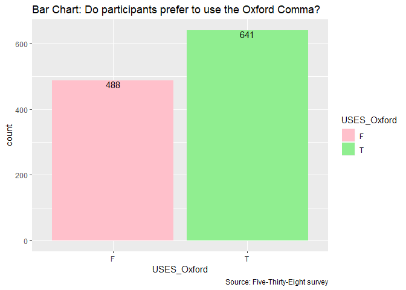

```r
myColors <- c("pink","lightgreen")
ggplot(tv_commadata, aes(x=USES_Oxford,fill=USES_Oxford)) +
  geom_bar()+
  scale_fill_manual(values=myColors) +
  geom_text(stat='count', aes(label=..count..), vjust=1) +
  labs(title="Bar Chart: Do participants prefer to use the Oxford Comma?",
       caption="Source: Five-Thirty-Eight survey")
```

#### Resequence the (unordered) levels for [4] `CARE_Oxford` to reflect the semantic ordering:

##### `forcats::fct_count()`: Count the number of responses of each type

```r
tv_commadata$CARE_Oxford %>% fct_count() %>%
  kable(col.names=c(initial_variable_names[4],"Count")) %>%
  kable_styling(c("striped", "bordered"))
```

| How much, if at all, do you care about the use (or lack thereof) of the serial (or Oxford) comma in grammar? | Count |
| --- | --- |
| Some | 414 |
| Not much | 268 |
| A lot | 291 |
| Not at all | 126 |
| NA | 30 |

Note that the sequence in which the responses are listed (“Some”,“Not Much”,“A lot”,“Not at all”) does not reflect their semantic ordering.  
We would like to list the values in the sequence from worst to best, i.e.,

- “Not at all”,
- “Not much”,
- “Some”,
- “A lot” , followed by
- NA.

##### `fct_relevel`: Resequence the levels for the factor

###### to reflect how much does the participant *care about* the Oxford Comma

```r
### use fct_relevel from library `forcats` to sort the CARE_Oxford levels ordinally
tv_commadata$CARE_Oxford <- tv_commadata$CARE_Oxford %>%
  fct_relevel(levels(tv_commadata$CARE_Oxford)[c(4,2,1,3)])
### display results
tv_commadata$CARE_Oxford %>% fct_count() %>%
  kable(col.names=c(new_variable_names[4],"Count")) %>%
  kable_styling(c("striped", "bordered"))
```

| CARE_Oxford | Count |
| --- | --- |
| Not at all | 126 |
| Not much | 268 |
| Some | 414 |
| A lot | 291 |
| NA | 30 |

##### Plot result using ggplot2

###### Use theme(plot.title = element_text(size = 10))

###### to prevent long text from overflowing the page

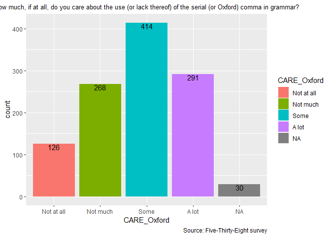

```r
ggplot(tv_commadata, aes(x=CARE_Oxford,fill=CARE_Oxford)) +
  geom_bar()+
  geom_text(stat='count', aes(label=..count..), vjust=1) +
  labs(title=initial_variable_names[4],
       caption="Source: Five-Thirty-Eight survey")+
  theme(plot.title = element_text(hjust = 0.5, size = 10))
```

#### Recategorize the responses to [5] `DATA_Sentence` to reflect “PLURAL” or “SINGULAR”

##### `forcats::fct_count()`: Count the number of responses of each type

```r
tv_commadata$DATA_Sentence %>% fct_count() %>%
  kable(col.names=c(initial_variable_names[5],"Count")) %>%
  kable_styling(c("striped", "bordered"))
```

| How would you write the following sentence? | Count |
| --- | --- |
| Some experts say it’s important to drink milk, but the data is inconclusive. | 865 |
| Some experts say it’s important to drink milk, but the data are inconclusive. | 228 |
| NA | 36 |

##### Replace the above sentences with the word “SINGULAR” or “PLURAL” to reflect user preference

##### `forcats::fct_recode`: Recode levels as “SINGULAR” or “PLURAL”

```r
oldlevels5 <- tv_commadata$DATA_Sentence %>% levels()
tv_commadata$DATA_Sentence <- tv_commadata$DATA_Sentence %>%
  fct_recode("SINGULAR"=oldlevels5[1],"PLURAL"=oldlevels5[2])

### display results
tv_commadata$DATA_Sentence %>% fct_count() %>%
  kable(col.names=c(new_variable_names[5],"Count")) %>%
  kable_styling(c("striped", "bordered"))
```

| DATA_Sentence | Count |
| --- | --- |
| SINGULAR | 865 |
| PLURAL | 228 |
| NA | 36 |

##### Plot result using ggplot2

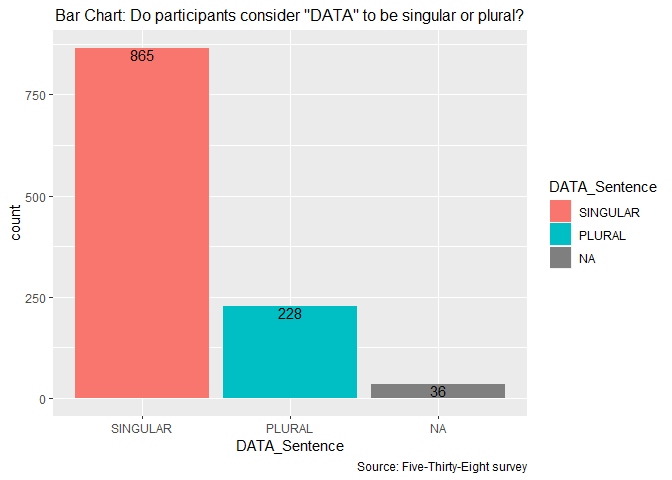

```r
ggplot(tv_commadata, aes(x=DATA_Sentence,fill=DATA_Sentence)) +
  geom_bar()+
  geom_text(stat='count', aes(label=..count..), vjust=1) +
  labs(title='Bar Chart: Do participants consider "DATA" to be singular or plural?',
       caption="Source: Five-Thirty-Eight survey")+
  theme(plot.title = element_text(hjust = 0.5, size = 12))
```

#### Resequence the (unordered) levels for [7] `DATA_Care` to reflect the semantic ordering:

##### `forcats::fct_count()`: Count the number of responses of each type

```r
tv_commadata$DATA_Care %>% fct_count() %>%
  kable(col.names=c(initial_variable_names[7],"Count")) %>%
  kable_styling(c("striped", "bordered"))
```

| How much, if at all, do you care about the debate over the use of the word “data” as a singluar or plural noun? | Count |
| --- | --- |
| Not much | 403 |
| Not at all | 203 |
| Some | 352 |
| A lot | 133 |
| NA | 38 |

Note that the sequence in which the responses are listed (“Not Much”,“Not at all”,“Some”,“A lot”) does not reflect their semantic ordering. We need to flip the sequence of the first two items, because we would like to list the values in the sequence from worst to best, i.e.,

- “Not at all”,
- “Not much”,
- “Some”,
- “A lot” , followed by
- NA.

##### `fct_relevel`: Resequence the levels for the factor `DATA_Care`

###### to reflect how much does the participant *care about* care about whether “Data” is considered Singular or Plural

```r
### use fct_relevel from library `forcats` to sort the DATA_Care levels ordinally
tv_commadata$DATA_Care <- tv_commadata$DATA_Care %>%
  fct_relevel(levels(tv_commadata$DATA_Care)[c(2,1,3,4)])
### display results
tv_commadata$DATA_Care %>% fct_count() %>%
  kable(col.names=c(new_variable_names[7],"Count")) %>%
  kable_styling(c("striped", "bordered"))
```

| DATA_Care | Count |
| --- | --- |
| Not at all | 203 |
| Not much | 403 |
| Some | 352 |
| A lot | 133 |
| NA | 38 |

##### Plot result using ggplot2

###### Use theme(plot.title = element_text(size = 10))

###### to prevent long text from overflowing the page

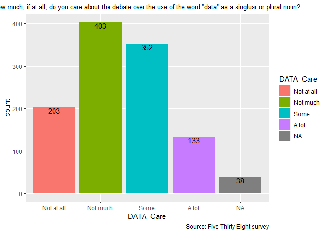

```r
ggplot(tv_commadata, aes(x=DATA_Care,fill=DATA_Care)) +
  geom_bar()+
  geom_text(stat='count', aes(label=..count..), vjust=1) +
  labs(title=initial_variable_names[7],
       caption="Source: Five-Thirty-Eight survey")+
  theme(plot.title = element_text(hjust = 0.5, size = 10))
```

#### Resequence the (unordered) levels for [8] `Grammar_Important` to reflect the semantic ordering

##### `forcats::fct_count()`: Count the number of responses of each type

```r
tv_commadata$Grammar_Important %>% fct_count() %>%
  kable(col.names=c(initial_variable_names[8],"Count")) %>%
  kable_styling(c("striped", "bordered"))
```

| In your opinion, how important or unimportant is proper use of grammar? | Count |
| --- | --- |
| Somewhat important | 333 |
| Somewhat unimportant | 7 |
| Very important | 688 |
| Very unimportant | 5 |
| Neither important nor unimportant (neutral) | 26 |
| NA | 70 |

Note that the sequence in which the responses are listed,

- “Somewhat important”,
- “Somewhat unimportant”,
- “Very important”,
- “Very unimportant”,
- “Neither important nor unimportant (neutral)”

does not reflect their semantic ordering. We need to reorder the sequence because we would like to list the values in the sequence from worst to best, i.e.,

- “Very unimportant”,
- “Somewhat unimportant”,
- “Neither important nor unimportant (neutral)”
- “Somewhat important”,
- “Very important”, followed by
- NA.

##### `forcats::fct_recode`: Recode level "“Neither important nor unimportant (neutral)” as “NEUTRAL” because it is too long

```r
oldlevels8 <- tv_commadata$Grammar_Important %>% levels()
tv_commadata$Grammar_Important <- tv_commadata$Grammar_Important %>%
  fct_recode("NEUTRAL"=oldlevels8[5])

### display results
tv_commadata$Grammar_Important %>% fct_count() %>%
  kable(col.names=c(new_variable_names[8],"Count")) %>%
  kable_styling(c("striped", "bordered"))
```

| Grammar_Important | Count |
| --- | --- |
| Somewhat important | 333 |
| Somewhat unimportant | 7 |
| Very important | 688 |
| Very unimportant | 5 |
| NEUTRAL | 26 |
| NA | 70 |

##### `fct_relevel`: Resequence the (unordered) levels for [8] `Grammar_Important` to reflect the ordering:

```r
### use fct_relevel from library `forcats` to sort the Grammar_Important levels ordinally
tv_commadata$Grammar_Important <- tv_commadata$Grammar_Important %>%
  fct_relevel(levels(tv_commadata$Grammar_Important)[c(4,2,5,1,3)])
### display results
tv_commadata$Grammar_Important %>% fct_count() %>%
  kable(col.names=c(new_variable_names[8],"Count")) %>%
  kable_styling(c("striped", "bordered"))
```

| Grammar_Important | Count |
| --- | --- |
| Very unimportant | 5 |
| Somewhat unimportant | 7 |
| NEUTRAL | 26 |
| Somewhat important | 333 |
| Very important | 688 |
| NA | 70 |

##### Plot result using ggplot2

###### use coord_flip() to make the bars horizontal, to make space for the headings

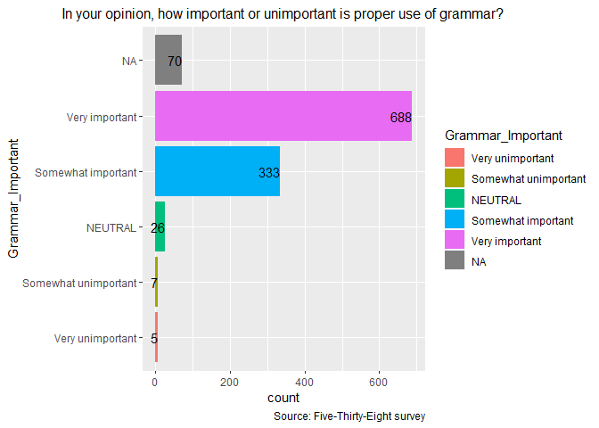

```r
ggplot(tv_commadata, aes(x=Grammar_Important,fill=Grammar_Important)) +
  geom_bar()+
  geom_text(stat='count', aes(label=..count..), hjust=1) +
  labs(title=initial_variable_names[8],
       caption="Source: Five-Thirty-Eight survey")+
  theme(plot.title = element_text(hjust = 0.5, size = 12))+
  coord_flip()
```

#### Resequence the (unordered) levels for [10] `AgeBands` to reflect the ordering of the bands:

##### `forcats::fct_count()`: Count the number of responses of each type

```r
tv_commadata$AgeBands %>% fct_count() %>%
  kable(col.names=c(initial_variable_names[10],"Count")) %>%
  kable_styling(c("striped", "bordered"))
```

| Age | Count |
| --- | --- |
| 30-44 | 254 |
| 18-29 | 221 |
| > 60 | 272 |
| 45-60 | 290 |
| NA | 92 |

Note that the above Age Bands are not listed in sequence from youngest to oldest.

We need to resequence the levels in order to fix this:

```r
### use fct_relevel from library `forcats` to sort the AgeBands levels ordinally
tv_commadata$AgeBands <- tv_commadata$AgeBands %>%
  fct_relevel(levels(tv_commadata$AgeBands)[c(2,1,4,3,5)])
### display results
tv_commadata$AgeBands %>% fct_count() %>%
  kable(col.names=c(new_variable_names[10],"Count")) %>%
  kable_styling(c("striped", "bordered"))
```

| AgeBands | Count |
| --- | --- |
| 18-29 | 221 |
| 30-44 | 254 |
| 45-60 | 290 |
| > 60 | 272 |
| NA | 92 |

##### Plot the Age of participants using ggplot2

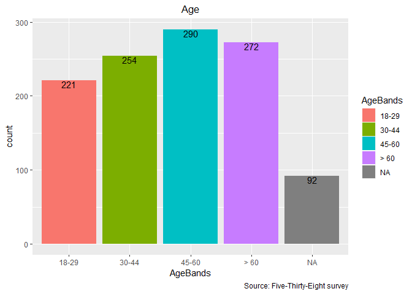

```r
ggplot(tv_commadata, aes(x=AgeBands,fill=AgeBands)) +
  geom_bar()+
  geom_text(stat='count', aes(label=..count..), vjust=1) +
  labs(title=initial_variable_names[10],
       caption="Source: Five-Thirty-Eight survey")+
  theme(plot.title = element_text(hjust = 0.5, size = 12))
```

#### Resequence the (unordered) levels for [11] `IncomeBands` to reflect the ordering of Income, from lowest to highest:

##### `forcats::fct_count()`: Count the number of responses of each type

```r
tv_commadata$IncomeBands %>% fct_count() %>%
  kable(col.names=c(initial_variable_names[11],"Count")) %>%
  kable_styling(c("striped", "bordered"))
```

| Household Income | Count |
| --- | --- |
| $50,000 - $99,999 | 290 |
| $25,000 - $49,999 | 158 |
| $0 - $24,999 | 121 |
| $150,000+ | 103 |
| $100,000 - $149,999 | 164 |
| NA | 293 |

Note that the above Income Bands are not listed in sequence from lowest to highest.

We need to resequence the levels in order to fix this:

```r
### use fct_relevel from library `forcats` to sort the IncomeBands levels ordinally
tv_commadata$IncomeBands <- tv_commadata$IncomeBands %>%
  fct_relevel(levels(tv_commadata$IncomeBands)[c(3,2,1,5,4,6)])
### display results
tv_commadata$IncomeBands %>% fct_count() %>%
  kable(col.names=c(new_variable_names[11],"Count")) %>%
  kable_styling(c("striped", "bordered"))
```

| IncomeBands | Count |
| --- | --- |
| $0 - $24,999 | 121 |
| $25,000 - $49,999 | 158 |
| $50,000 - $99,999 | 290 |
| $100,000 - $149,999 | 164 |
| $150,000+ | 103 |
| NA | 293 |

##### Plot the Income of participants using ggplot2

###### use axis.text.x=element_text(angle=30) to rotate the column headings

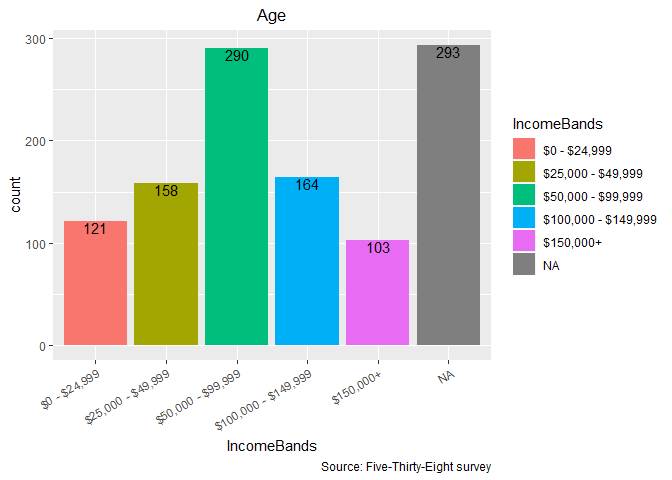

```r
ggplot(tv_commadata, aes(x=IncomeBands,fill=IncomeBands)) +
  geom_bar()+
  geom_text(stat='count', aes(label=..count..), vjust=1) +
  labs(title=initial_variable_names[10],
       caption="Source: Five-Thirty-Eight survey")+
  theme(plot.title = element_text(hjust = 0.5, size = 12),
        axis.text.x=element_text(angle=30, hjust=1))
```

#### Resequence the (unordered) levels for [12] `Education` to reflect the ordering of Educational Attainment:

##### `forcats::fct_count()`: Count the number of responses of each type

```r
tv_commadata$Education %>% fct_count() %>%
  kable(col.names=c(initial_variable_names[12],"Count")) %>%
  kable_styling(c("striped", "bordered"))
```

| Education | Count |
| --- | --- |
| Bachelor degree | 344 |
| Graduate degree | 276 |
| Less than high school degree | 11 |
| Some college or Associate degree | 295 |
| High school degree | 100 |
| NA | 103 |

Note that the above Education levels are not listed in sequence from lowest to highest.

We need to resequence the levels in order to obtain the desired sequence:

```r
### use fct_relevel from library `forcats` to sort the Education levels ordinally
tv_commadata$Education <- tv_commadata$Education %>%
  fct_relevel(levels(tv_commadata$Education)[c(3,5,4,1,2,6)])
### display results
tv_commadata$Education %>% fct_count() %>%
  kable(col.names=c(new_variable_names[12],"Count")) %>%
  kable_styling(c("striped", "bordered"))
```

| Education | Count |
| --- | --- |
| Less than high school degree | 11 |
| High school degree | 100 |
| Some college or Associate degree | 295 |
| Bachelor degree | 344 |
| Graduate degree | 276 |
| NA | 103 |

#### Plot the Education Level of participants using ggplot2

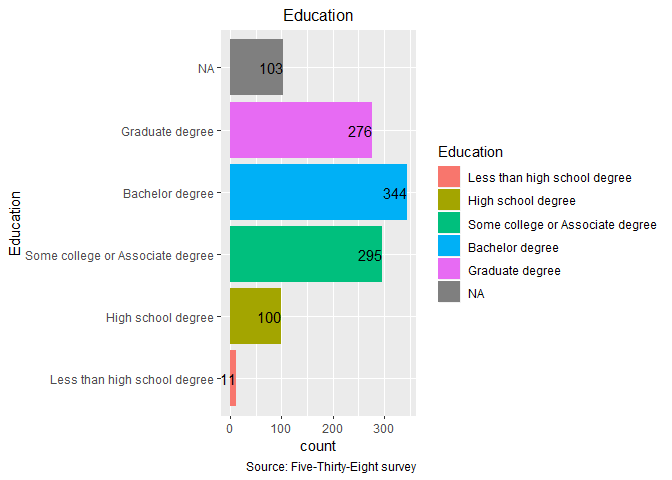

```r
ggplot(tv_commadata, aes(x=Education,fill=Education)) +
  geom_bar()+
  geom_text(stat='count', aes(label=..count..), hjust=1) +
  labs(title=initial_variable_names[12],
       caption="Source: Five-Thirty-Eight survey")+
  theme(plot.title = element_text(hjust = 0.5, size = 12))+
  coord_flip()
```

#### Resequence the (unordered) levels for [13] `Location` to reflect to reflect geography (east coast to west coast):

##### `forcats::fct_count()`: Count the number of responses of each type

```r
tv_commadata$Location %>% fct_count() %>%
  kable(col.names=c(initial_variable_names[13],"Count")) %>%
  kable_styling(c("striped", "bordered"))
```

| Location (Census Region) | Count |
| --- | --- |
| South Atlantic | 164 |
| Mountain | 87 |
| East North Central | 170 |
| Middle Atlantic | 140 |
| New England | 73 |
| Pacific | 180 |
| East South Central | 43 |
| West North Central | 82 |
| West South Central | 88 |
| NA | 102 |

Note that the above Locations levels are not listed to reflect geography (east coast to west coast; north to south):

We need to resequence the levels in order to obtain the desired sequence:

- New England,
- Middle Atlantic,
- South Atlantic,
- East North Central,
- East South Central,
- West North Central,
- West South Central,
- Mountain,
- Pacific, followed by
- NA

```r
### use fct_relevel from library `forcats` to sort the Location data geographically
tv_commadata$Location <- tv_commadata$Location %>%
  fct_relevel(levels(tv_commadata$Location)[c(5,4,1,3,7,8,9,2,6)])
### display results
tv_commadata$Location %>% fct_count() %>%
  kable(col.names=c(new_variable_names[13],"Count")) %>%
  kable_styling(c("striped", "bordered"))
```

| Location | Count |
| --- | --- |
| New England | 73 |
| Middle Atlantic | 140 |
| South Atlantic | 164 |
| East North Central | 170 |
| East South Central | 43 |
| West North Central | 82 |
| West South Central | 88 |
| Mountain | 87 |
| Pacific | 180 |
| NA | 102 |

#### Plot the Location of respondents using ggplot2

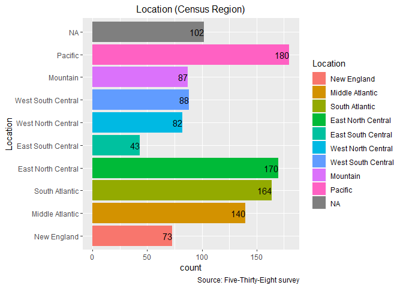

```r
ggplot(tv_commadata, aes(x=Location,fill=Location)) +
  geom_bar()+
  geom_text(stat='count', aes(label=..count..), hjust=1) +
  labs(title=initial_variable_names[13],
       caption="Source: Five-Thirty-Eight survey")+
  theme(plot.title = element_text(hjust = 0.5, size = 12))+
  coord_flip()
```

#### [1] `RespondentID` should not impact the results – it is just an identifier, so drop it

##### `dplyr::select(-[columnname])`: Drop variable [1] `RespondentID`

```r
tv_commadata <- tv_commadata %>% select(-RespondentID)
```

### *References*

1. Hickey, Walt, “Elitist, Superfluous, Or Popular? We Polled Americans on the Oxford Comma” (June 17, 2014), FiveThirtyEight.com . Retrieved December 1, 2019, from https://fivethirtyeight.com/features/elitist-superfluous-or-popular-we-polled-americans-on-the-oxford-comma/.
2. FiveThirtyEight.com survey of Oxford Comma Usage (2014, June). Retrieved December 1, 2019, from https://raw.githubusercontent.com/fivethirtyeight/data/master/comma-survey/comma-survey.csv.

# End of Part 1